# Logistic Regression - Predicting Diabetes Diagnosis

Date: May 13, 2024

Becca Godfrey

## Data Cleaning/Preparation

**Data Cleaning/Preparation:**

First, I imported “diabetes.csv” file into the R environment. I then converted the height variable to International System of Units (SI units) by multiplying it by 0.0254, resulting in values ranging from approximately 1.32 to 1.93 meters. Secondly, I converted the weight variable to SI units by multiplying it by 0.453592.

Next, I calculated the Body Mass Index (BMI) for each individual. I then categorized the BMI variable into four categories: underweight, normal, overweight, and obese. I also recoded the insurance and smoking variables to reflect their value labels. For the insurance variable, the categories were recoded as none, government, and private. Regarding the smoking variable, the categories were recoded as current smokers, never smokers, and ex-smokers.

These steps allowed for the data to be properly organized and categorized to make future analysis more clear and easier for an audience to interpret.

```r
# Importing diabetes.csv
diabetes <- read.csv("diabetes.csv")

# Converting height to SI units
diabetes$height.si <- diabetes$height * 0.0254

# Converting weight to SI units
diabetes$weight.si <- diabetes$weight * 0.453592

# Calculating BMI
diabetes$BMI <- diabetes$weight.si / (diabetes$height.si^2)

# Creating categorical BMI variable
diabetes$bmi_categorized <- cut(diabetes$BMI,
                                 breaks = c(-Inf, 18.5, 25, 30, Inf),
                                 labels = c("underweight", "normal", "overweight", "obese"),
                                 include.lowest = TRUE)

# Recoding insurance variable
diabetes$insurance <- factor(diabetes$insurance, levels = c(0, 1, 2), labels = c("none", "government", "private"))

# Recoding smoking variable
diabetes$smoking <- factor(diabetes$smoking, levels = c(1, 2, 3), labels = c("current", "never", "ex-smoker"))

# Checks
summary(diabetes$height.si)
summary(diabetes$weight.si)
summary(diabetes$BMI)
table(diabetes$bmi_categorized)
table(diabetes$insurance)
table(diabetes$smoking)
```

[output not shown]

## Exploratory Data Analysis

The dataset contains 403 observations. 37.72% of the individuals in the dataset are classified as obese based on their BMI. About 58.06% of the individuals in the dataset are female. The percentage of individuals with diabetes in the dataset is approximately 14.89%. The average age of individuals in the dataset is 46.85 years. The average BMI for individuals in the dataset is approximately 28.79. These findings provide a preliminary understanding of the demographic, laying the groundwork for further analysis and interpretation.

```r
# Number of observations
num_observations <- nrow(diabetes)
num_observations
# Percentage of individuals who are obese
percentage_underweight <- sum(diabetes$bmi_categorized == "underweight", na.rm = TRUE) / num_observations * 100
percentage_normal <- sum(diabetes$bmi_categorized == "normal", na.rm = TRUE) / num_observations * 100
percentage_overweight <- sum(diabetes$bmi_categorized == "overweight", na.rm = TRUE) / num_observations * 100
percentage_obese <- sum(diabetes$bmi_categorized == "obese", na.rm = TRUE) / num_observations * 100

percentage_underweight
percentage_normal
percentage_overweight
percentage_obese

# Percentage of gender
percentage_female <- sum(diabetes$gender == "female") / num_observations * 100
percentage_female
percentage_male <- sum(diabetes$gender == "male") / num_observations * 100
percentage_male
# Percentage of individuals with diabetes
percentage_diabetes <- sum(diabetes$dm == 1, na.rm = TRUE) / length(diabetes$dm) * 100
percentage_diabetes
percentage_no_diabetes <- sum(diabetes$dm == 0, na.rm = TRUE) / length(diabetes$dm) * 100
percentage_no_diabetes

# Average age
average_age <- mean(diabetes$age)
average_age
# Average BMI
average_bmi <- mean(diabetes$BMI, na.rm = TRUE)
average_bmi
```

[output not shown]

## Data Visualization

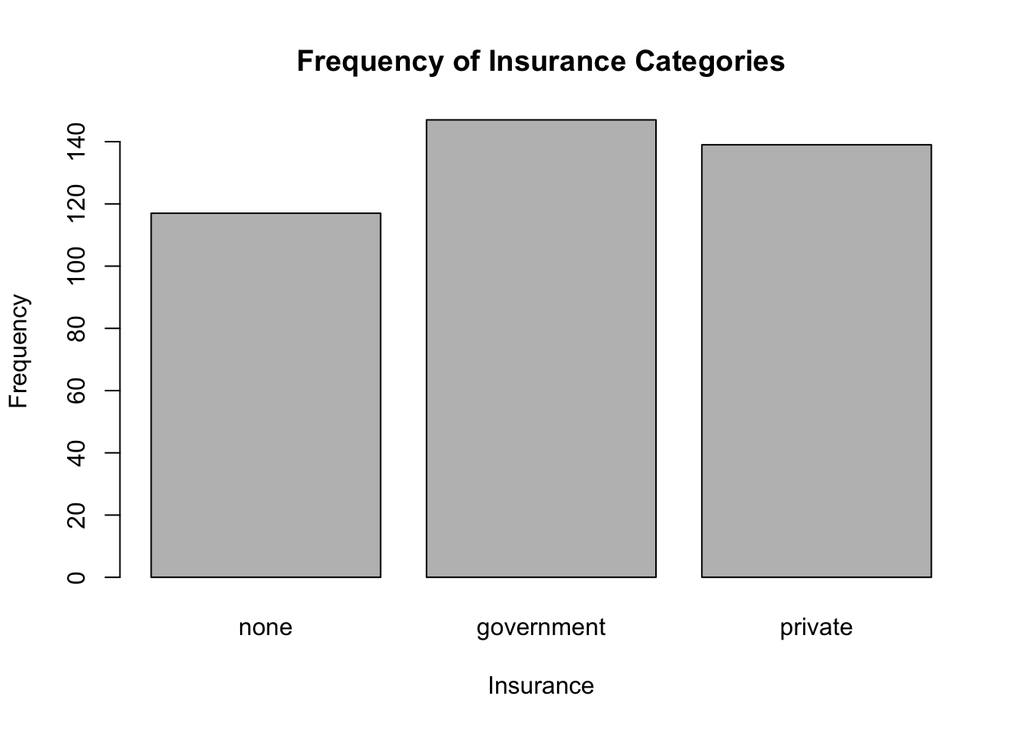

```r
# Plotting frequency of Insurance Categories
barplot(table(diabetes$insurance), main = "Frequency of Insurance Categories", xlab = "Insurance", ylab = "Frequency")
```

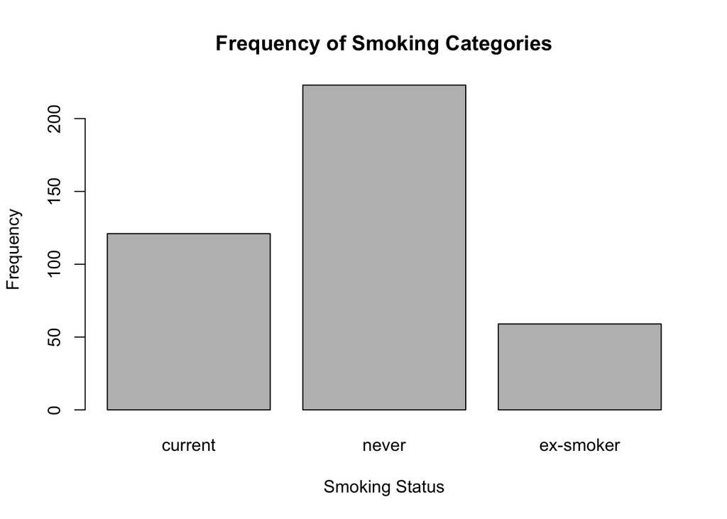

```r
# Plotting frequency of Smoking Categories
barplot(table(diabetes$smoking), main = "Frequency of Smoking Categories", xlab = "Smoking Status", ylab = "Frequency")
```

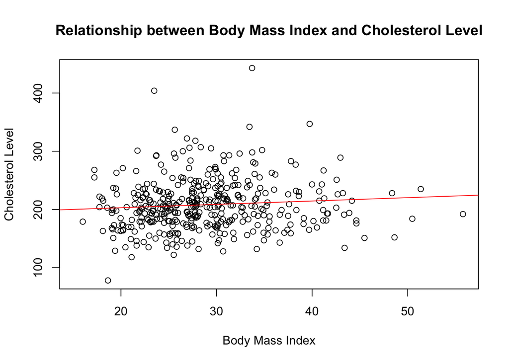

```r
# Scatter plot of BMI vs Cholesterol with regression line
plot(diabetes$BMI, diabetes$chol, xlab = "Body Mass Index", ylab = "Cholesterol Level", main = "Relationship between Body Mass Index and Cholesterol Level")
abline(lm(chol ~ BMI, data = diabetes), col = "red")
```

```r
# Calculate correlation coefficient
cleaned_data <- diabetes[complete.cases(diabetes$BMI, diabetes$chol), ]
correlation <- cor(cleaned_data$BMI, cleaned_data$chol)
correlation
```

```
## [1] 0.08593146
```

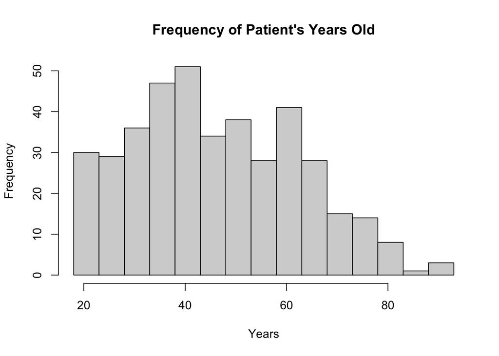

```r
# Histogram of Patient Age in Years
min_age <- min(diabetes$age)
max_age <- max(diabetes$age)
hist(diabetes$age, breaks = seq(min_age - 1, max_age + 1, by = 5), xlab = "Years", ylab = "Frequency", main = "Frequency of Patient's Years Old")
```

## Logistic Regression Results

The logistic regression model was constructed to predict the likelihood of diabetes diagnosis based on age, gender, and BMI. The slope coefficient estimate for age is 0.055454. This suggests that for each additional year of age, the odds of being diagnosed with diabetes increases by 0.055454. The coefficient estimate for the male gender is 0.244852. However, the p-value associated with gender is 0.44816, indicating that gender is not statistically significant in predicting diabetes diagnosis at a significance level of a = 0.05. The coefficient estimate for BMI is 0.073879. This means that for every increase in BMI by one unit , the odds of being diagnosed with diabetes increases by 0.073879. Age and BMI are found to be statistically significant predictors of diabetes diagnosis, as indicated by their p-values.

```r
# Building logistic regression model
model <- glm(dm ~ age + gender + BMI, data = diabetes, family = "binomial")

# Interpretation of slope coefficients
summary(model)
```

[output not shown]